# Week5HW_JaeHyunLee

Lee

2019 11 11

## 8.1

### a

Which do you think is bigger $\operatorname{Var}[y_{i,j} | \theta_i , \sigma^2]$ or $\operatorname{Var}[y_{i,j} | \mu, \tau^2]$?

> 후자는 그룹들간의 분산을 포함하므로 더 크다.

### b

Do you think $\operatorname{Cov}[y_{i_1, j} , y_{i_2,j} | \theta_j , \sigma^2]$ is negative or positive or zero?

> Exchangeability에 의해서 Conditional independent

Do you think $\operatorname{Cov}[y_{i_1, j} , y_{i_2,j} | \mu, \tau]$ is negative or positive or zero?

$p(y_{i_2, j} | \mu, \tau) \neq p(y_{i_2, j} |y_{i_1, j} ,\mu, \tau)$

> 그러므로 0이 아니라고 생각한다. posterior 분포는 sample에 다가가면서 결정되므로그러므로 양수라고 생각한다.

### c

> $\operatorname{Var}[y_{i,j} | \theta_i , \sigma^2] = \sigma ^2$

> $\operatorname{Var}[\bar y_{\cdot,j} | \theta_i , \sigma^2] = \frac{\sigma ^2}{n_j}$

> $\operatorname{Cov}[y_{i_1, j}, y_{i_2, j}| \theta_j, \sigma^2] = 0 \quad \because \text{Exchangeability}$

> $\begin{align}\operatorname{Var}[y_{ij} | \mu , \tau^2] &= \operatorname{Var}[\operatorname{E}[y_{ij} | \mu_j , \sigma]|\mu, \tau^2] +\operatorname{E}[\operatorname{Var}[y_{ij} | \mu_j , \sigma]|\mu, \tau^2] \\ &= \operatorname{Var}[\mu_j | \mu , \tau^2] + \operatorname{E}[\sigma^2] \\ &= \tau^2 + \operatorname{E}[\sigma^2]\end{align}$

> $\begin{align}\operatorname{Var}[\bar y_{\cdot,j} | \mu , \tau^2] &= \operatorname{Var}[\operatorname{E}[\bar y_{\cdot,j} | \mu_j , \sigma]|\mu, \tau^2] +\operatorname{E}[\operatorname{Var}[\bar y_{\cdot,j} | \mu_j , \sigma]|\mu, \tau^2] \\ &= \operatorname{Var}[\mu_j | \mu , \tau^2] + \operatorname{E}[\sigma^2]/n_j \\ &= \tau^2 + \operatorname{E}[\sigma^2] / n_j\end{align}$

> $\begin{align} \operatorname{Cov}[y_{i_1, j}, y_{i_2, j}| \mu, \tau^2] &= \operatorname{Cov}[\operatorname{E}[y_{i_1, j} | \theta_j, \sigma^2 ] \times \operatorname{E}[y_{i_2, j} | \theta_j, \sigma^2 ] |\mu, \tau^2 ] + \operatorname{E} [\operatorname{Cov(y_{i_1, j}, y_{i_2,j}|\theta_j , \sigma^2)}|\mu, \tau^2] \\ &= \operatorname{Cov}[\operatorname{E}[y_{i_1, j} | \theta_j, \sigma^2 ] \times \operatorname{E}[y_{i_2, j} | \theta_j, \sigma^2 ] |\mu, \tau^2 ] + 0 \\&= \operatorname{Cov}[\operatorname{E}[y_{i_1, j} | \theta_j, \sigma^2 ] \times \operatorname{E}[y_{i_2, j} | \theta_j, \sigma^2 ] |\mu, \tau^2 ] \\ &= \operatorname{Cov[\theta_j , \theta_j | \mu, \tau^2]} \\ &= \tau^2 \end{align}$

### d

Interpret $p(\mu | \theta_1 , \cdots, \theta_m , \sigma^2, \tau^2, \boldsymbol y_1, \cdots, \boldsymbol y_m) = p(\mu | \theta_1, \cdots, \theta_m , \tau^2)$

$\theta_1, \cdots \theta_m, \tau^2$이 주어지면 $\mu$는 나머지에 대해서 독립이다. 그래프를 그려보면 쉽게 보인다.

## 8.3

```r
library(tidyverse)
```

```r
school = list()
for(i in 1:8){
    url = paste0('http://www2.stat.duke.edu/~pdh10/FCBS/Exercises/school', as.character(i), '.dat')
    school[paste0('school', as.character(i))] = read.csv(url)
}
```

```r
school_df <- data_frame(id = seq_along(school), school) %>% unnest %>% as.data.frame()
colnames(school_df) <- c('school_id', 'score')
```

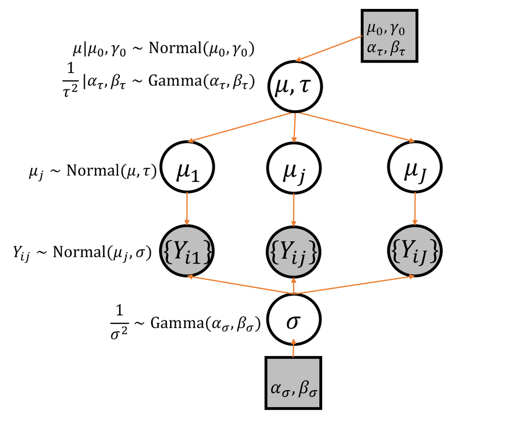

```r
modelString <- "
model{

## likelihood
for (i in 1:N){
y[i] ~ dnorm(mu_j[id[i]], invsigma2)
}

##hyperprior
mu ~ dnorm(mu0, 1/g0^2)
invtau2 ~ dgamma(a_t, b_t)
tau <- sqrt(pow(invtau2, -1))

##prior
for (j in 1:J){
mu_j[j] ~ dnorm(mu, invtau2)
}
invsigma2 ~ dgamma(a_g, b_g)
sigma <- sqrt(pow(invsigma2, -1))
}
"
```

```r
y <- school_df %>% pull(score)
id <- school_df %>% pull(school_id)
N <- length(y)
J <- length(unique(id))

initsfunction <- function(chain){
    .RNG.seed <- c(1,2)[chain]
    .RNG.name <- c('base::Super-Duper',
                   'base::Wichmann-Hill')[chain]
    return(list(.RNG.seed=.RNG.seed,
                .RNG.name=.RNG.name))
}

the_data <- list('y'=y, 'id'=id, 'N'=N, 'J'=J,
                 'mu0'=7, 'g0'=sqrt(5),
                 'a_t'=1, 'b_t'=10,
                 'a_g'=1, 'b_g'=15)
```

```r
library(runjags)
runjags.options(silent.runjags=TRUE, silent.jags=TRUE)
posterior <- run.jags(modelString,
                      n.chains = 1,
                      data = the_data,
                      monitor = c('mu', 'tau', 'mu_j', 'sigma'),
                      adapt = 1000,
                      burnin = 5000,
                      sample = 5000,
                      thin = 1,
                      inits = initsfunction)
```

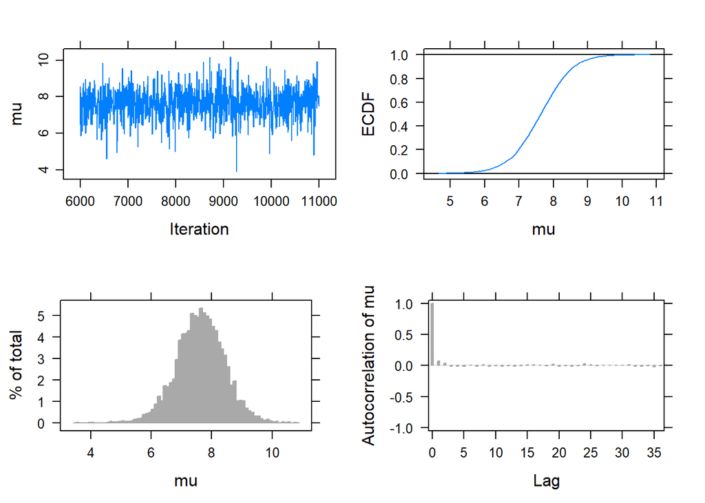

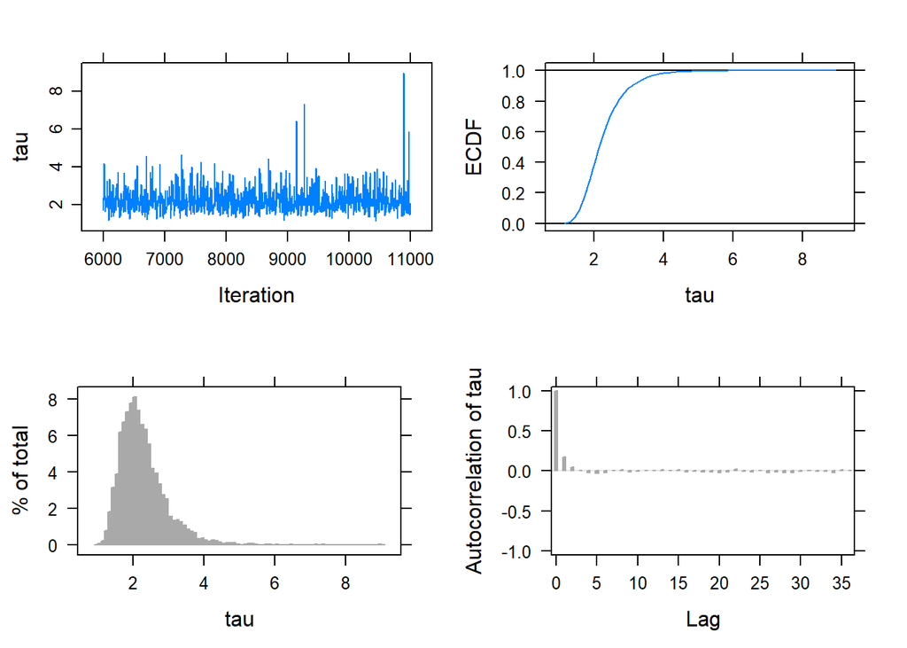

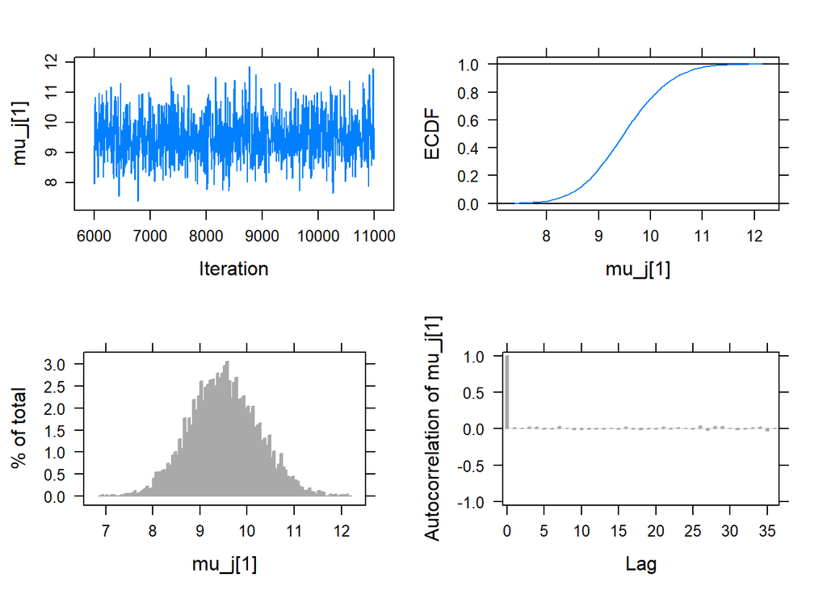

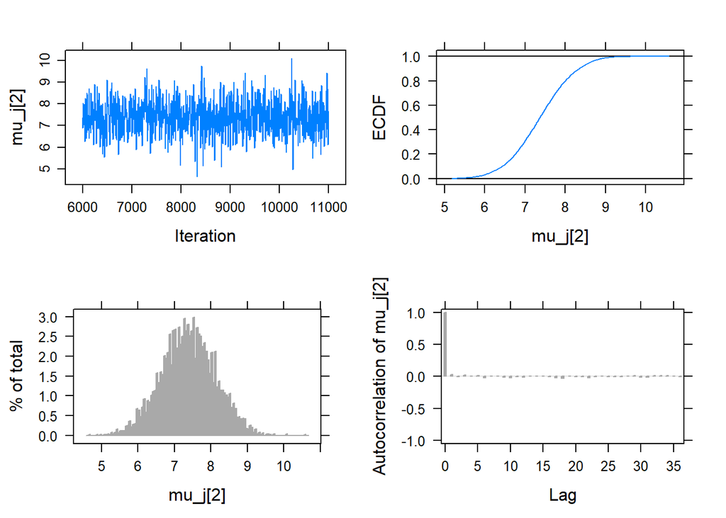

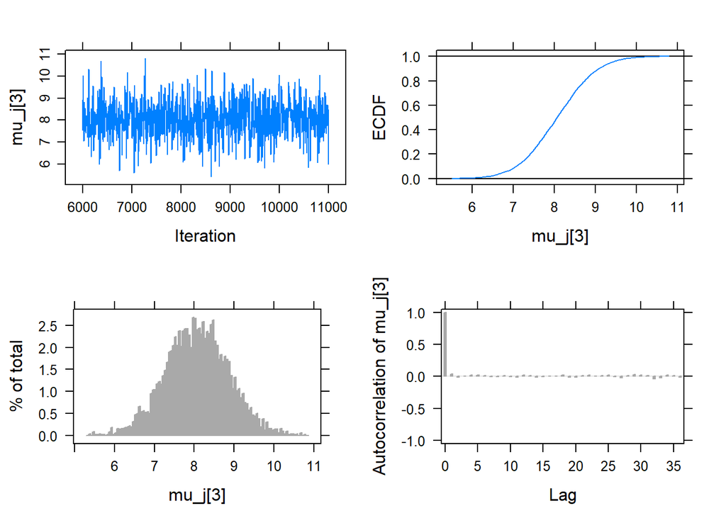

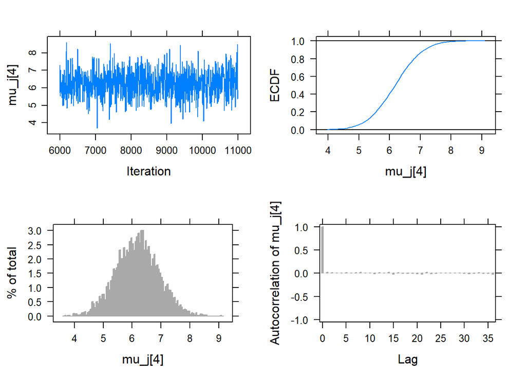

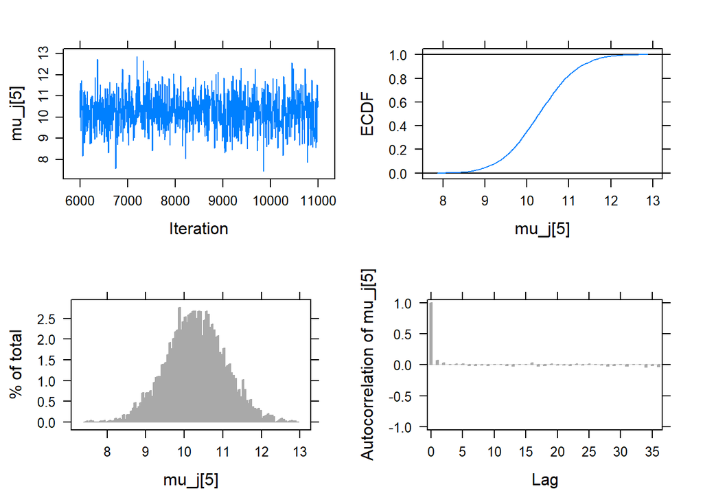

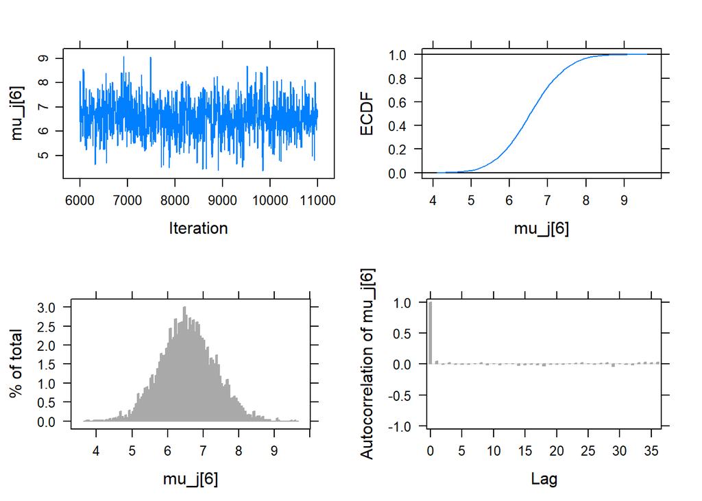

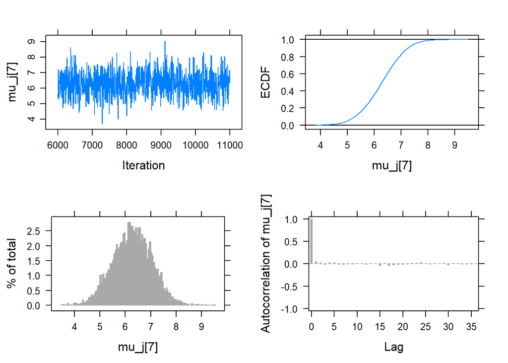

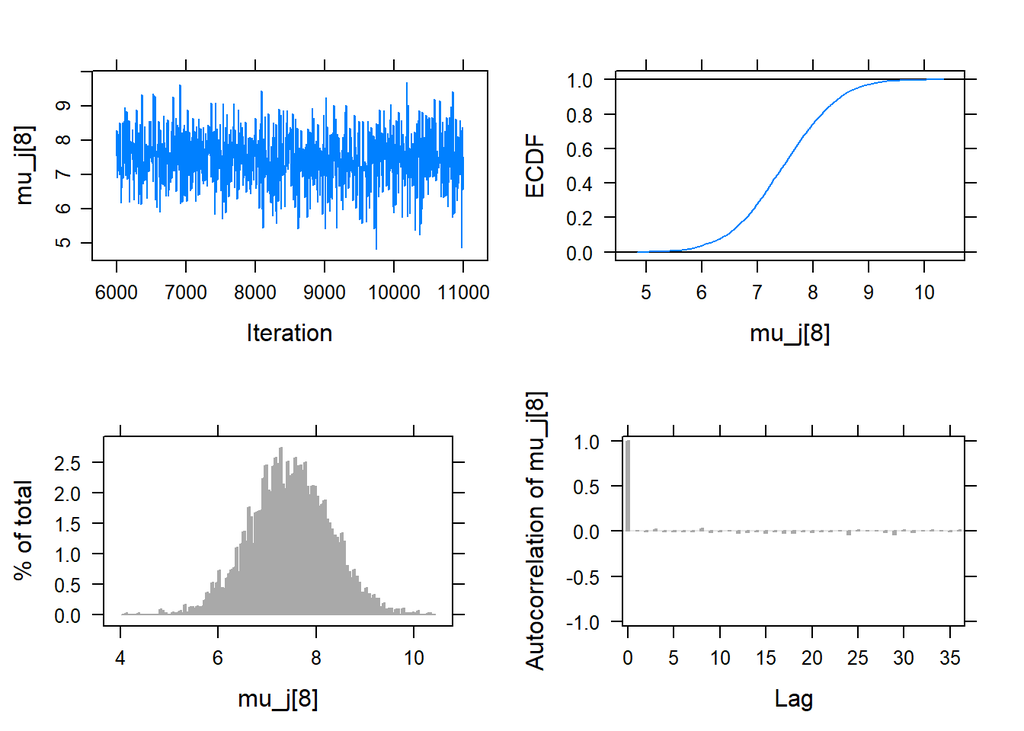

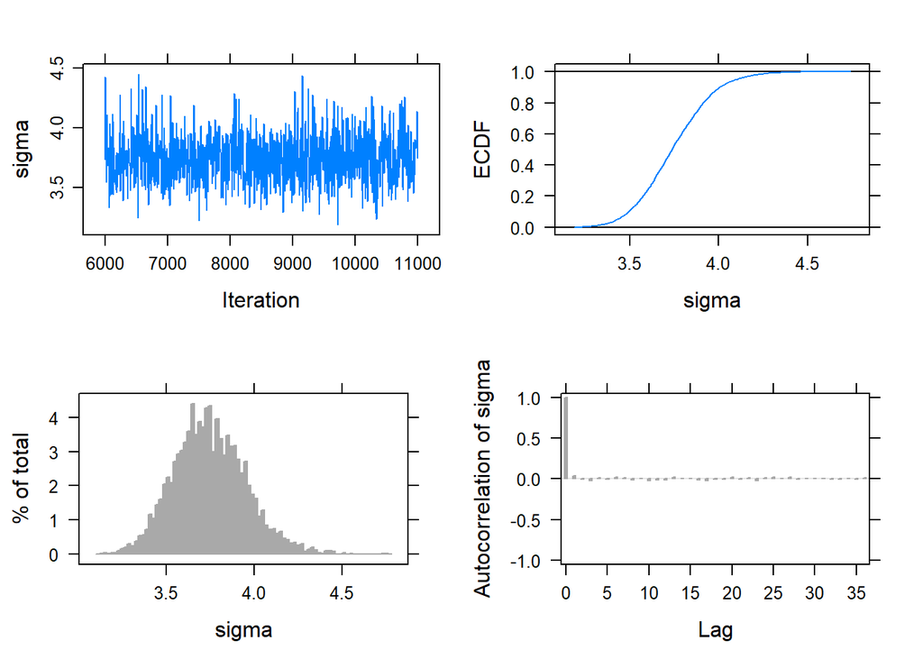

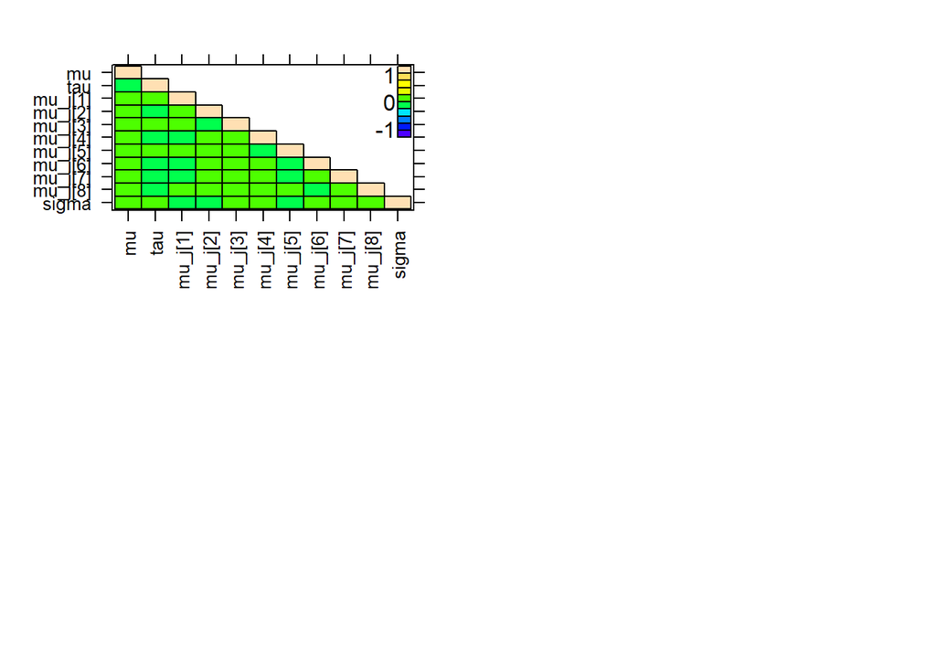

```r
plot(posterior)
```

```r
summary(posterior)
```

```
##          Lower95    Median   Upper95      Mean        SD Mode       MCerr
## mu      6.040035  7.638099  9.222198  7.624464 0.8029588   NA 0.012362150
## tau     1.258839  2.152365  3.524864  2.271964 0.6441045   NA 0.010807059
## mu_j[1] 8.051678  9.492974 10.900951  9.508930 0.7313195   NA 0.010342419
## mu_j[2] 5.951712  7.372531  8.835135  7.377135 0.7429200   NA 0.010805051
## mu_j[3] 6.531639  8.067279  9.649177  8.071639 0.7982023   NA 0.011696778
## mu_j[4] 4.749271  6.189405  7.670789  6.182235 0.7444614   NA 0.010528274
## mu_j[5] 8.769799 10.290673 11.775202 10.296428 0.7637154   NA 0.011870273
## mu_j[6] 5.104746  6.546311  8.074346  6.561583 0.7687546   NA 0.011392385
## mu_j[7] 4.765856  6.284594  7.730529  6.276332 0.7699394   NA 0.011384272
## mu_j[8] 5.866561  7.473943  9.031224  7.471810 0.8089665   NA 0.011440514
## sigma   3.353745  3.738720  4.158306  3.748973 0.2052892   NA 0.003004981
##         MC%ofSD SSeff        AC.10 psrf
## mu          1.5  4219 -0.006189816   NA
## tau         1.7  3552 -0.005769064   NA
## mu_j[1]     1.4  5000 -0.015971133   NA
## mu_j[2]     1.5  4727 -0.019133041   NA
## mu_j[3]     1.5  4657 -0.006212022   NA
## mu_j[4]     1.4  5000  0.007745389   NA
## mu_j[5]     1.6  4139  0.006572935   NA
## mu_j[6]     1.5  4554  0.001465852   NA
## mu_j[7]     1.5  4574  0.002521400   NA
## mu_j[8]     1.4  5000 -0.002171411   NA
## sigma       1.5  4667 -0.019956981   NA
```

```r
summary_df <- data.frame(unclass(summary(posterior)))
print(summary_df['SSeff'])
```

```
##         SSeff
## mu       4219
## tau      3552
## mu_j[1]  5000
## mu_j[2]  4727
## mu_j[3]  4657
## mu_j[4]  5000
## mu_j[5]  4139
## mu_j[6]  4554
## mu_j[7]  4574
## mu_j[8]  5000
## sigma    4667
```

### b

```r
print(summary_df['Mean'])
```

```
##              Mean
## mu       7.624464
## tau      2.271964
## mu_j[1]  9.508930
## mu_j[2]  7.377135
## mu_j[3]  8.071639
## mu_j[4]  6.182235
## mu_j[5] 10.296428
## mu_j[6]  6.561583
## mu_j[7]  6.276332
## mu_j[8]  7.471810
## sigma    3.748973
```

```r
library(coda)
mu_draws <- as.mcmc(posterior, vars='mu')
mu_draws <- data.frame(mu_draws)$mu # why 'mu' includes mu_j

tau_draws <- as.mcmc(posterior, vars='tau')
tau_draws <- as.numeric(tau_draws)

sigma_draws <- as.mcmc(posterior, vars='sigma')
sigma_draws <- as.numeric(sigma_draws)
```

```r
temp1 <- as.numeric(quantile(mu_draws, c(0.025, 0.975)))

temp2 <- as.numeric(quantile(tau_draws, c(0.025, 0.975)))

temp3 <- as.numeric(quantile(sigma_draws, c(0.025, 0.975)))

quantile_df <- data.frame(mu = temp1, tau = temp2, sigma = temp3)
rownames(quantile_df) <- c('2.5%', '97.5%')

quantile_df
```

```
##             mu      tau    sigma
## 2.5%  6.009596 1.384395 3.376125
## 97.5% 9.199037 3.801499 4.186412
```

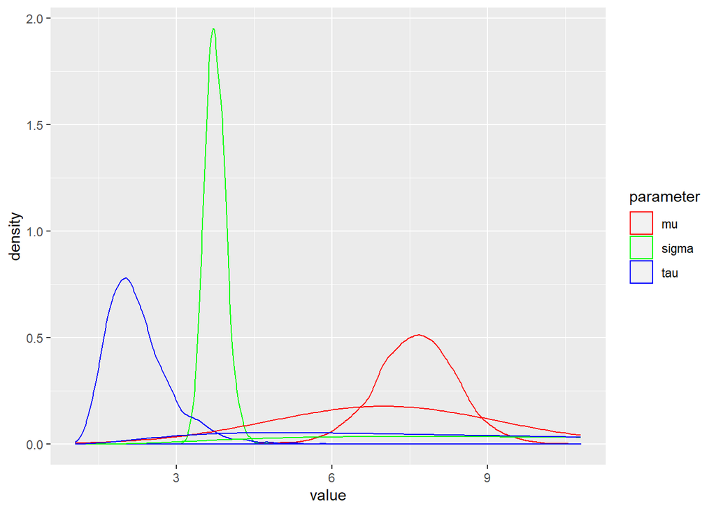

```r
library(invgamma)
temp_df <- data.frame(mu = mu_draws, tau = tau_draws, sigma = sigma_draws)

temp_df_long <- temp_df %>% gather(parameter, value, c('mu', 'tau', 'sigma'))

ggplot(temp_df_long, aes(value, color=parameter)) + geom_density() +
    scale_color_manual(values = c("red", "green", "blue")) +
    stat_function(fun=dnorm, args=list(mean=7, sd=sqrt(5)),
                  colour="red", size=0.5) +
    stat_function(fun=dinvgamma, args=list(shape=1, rate=15),
                  colour="green", size=0.5) +
    stat_function(fun=dinvgamma, args=list(shape=1, rate=10),
                  colour="blue", size=0.5)
```

### c

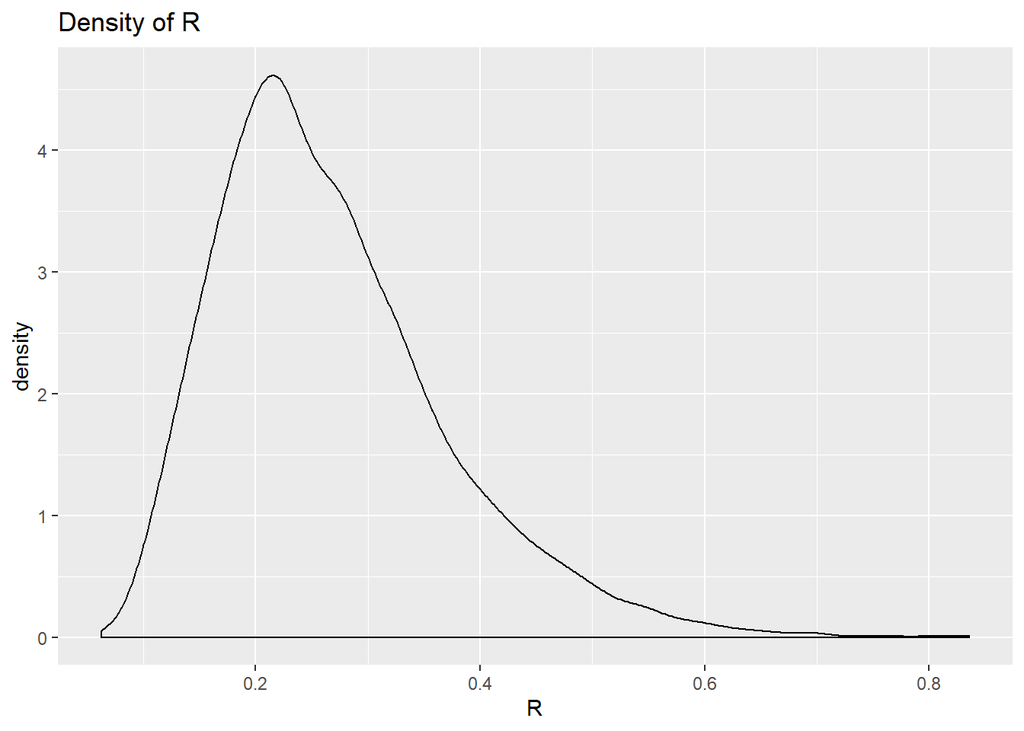

```r
R = tau_draws^2/(tau_draws^2 + sigma_draws^2)

df <- data.frame(R = R)
ggplot(df, aes(x=R)) +
  geom_density() +
  labs(title='Density of R')
```

그룹들 간의 variance보다는 그룹 내에서의 variance가 더 크다.

### d

$$p(\theta_6>\theta_7|\mathcal{D})$$

```r
mu_j_draws <- data.frame(as.mcmc(posterior, vars='mu_j'))

colnames(mu_j_draws) <- c('mu1', 'mu2', 'mu3', 'mu4', 'mu5', 'mu6', 'mu7', 'mu8')

mu_j_draws %>% transmute(bigger=mu6>mu7) %>% summarize(mean(bigger))
```

```
##   mean(bigger)
## 1       0.6038
```

```r
temp <- mu_j_draws %>% transmute(mu7<mu1, mu7<mu2, mu7<mu3, mu7<mu4, mu7<mu5,
                                  mu7<mu6, mu7<mu8)
head(temp)
```

```
##   mu7 < mu1 mu7 < mu2 mu7 < mu3 mu7 < mu4 mu7 < mu5 mu7 < mu6 mu7 < mu8
## 1      TRUE      TRUE      TRUE      TRUE      TRUE      TRUE      TRUE
## 2      TRUE     FALSE      TRUE     FALSE      TRUE     FALSE     FALSE
## 3      TRUE     FALSE      TRUE     FALSE      TRUE      TRUE     FALSE
## 4      TRUE     FALSE      TRUE     FALSE      TRUE      TRUE      TRUE
## 5      TRUE      TRUE      TRUE     FALSE      TRUE     FALSE      TRUE
## 6      TRUE      TRUE      TRUE      TRUE      TRUE      TRUE      TRUE
```

```r
mean(apply(temp, 1, all))
```

```
## [1] 0.3326
```

```r
temp2 <- mu_j_draws %>% transmute(mu4<mu1, mu4<mu2, mu4<mu3, mu4<mu5, mu4<mu6,
                                  mu4<mu7, mu4<mu8)
mean(apply(temp2, 1, all))
```

```
## [1] 0.389
```

### e

Shirinkage/pooling effects

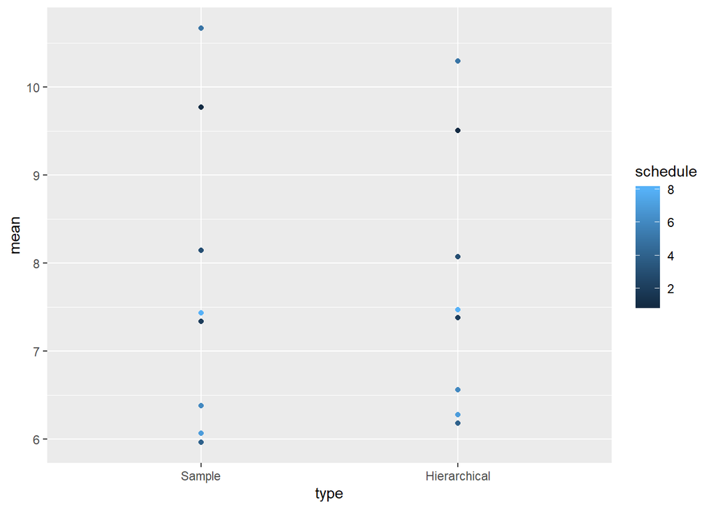

```r
temp1 <- data.frame(unclass(summary(posterior)), check.names = FALSE, stringsAsFactors = FALSE)[3:10,]$Mean
temp2 <- school_df %>% group_by(school_id) %>% summarize(mean(score))

temp3 <- cbind(temp2, temp1)
colnames(temp3) <- c('schedule', 'Sample', 'Hierarchical')

temp3 <- temp3 %>%
  gather(type, mean, c('Hierarchical', 'Sample'))
temp3$type <- factor(temp3$type, levels=c('Sample', 'Hierarchical'))
ggplot(data=temp3, aes(x=type, y=mean, color=schedule)) +
  geom_point()
```